# Medical Cost Analysis

true  
2023-03-18

# Intro

> This exploratory data analysis was done with the skills I obtained from both the Google Data Analysis Certificate program as well as University of Michigan Data Analytics in the Public Sector Certificate Program.

### Preparing my environment and taking a peek at the data

```r
library(tidyverse) # metapackage of all tidyverse packages
data <- read.csv("data/insurance.csv")
```

```r
#Checking the data
summary(data)
```

```
      age            sex                 bmi           children
 Min.   :18.00   Length:1338        Min.   :15.96   Min.   :0.000
 1st Qu.:27.00   Class :character   1st Qu.:26.30   1st Qu.:0.000
 Median :39.00   Mode  :character   Median :30.40   Median :1.000
 Mean   :39.21                      Mean   :30.66   Mean   :1.095
 3rd Qu.:51.00                      3rd Qu.:34.69   3rd Qu.:2.000
 Max.   :64.00                      Max.   :53.13   Max.   :5.000
    smoker             region             charges
 Length:1338        Length:1338        Min.   : 1122
 Class :character   Class :character   1st Qu.: 4740
 Mode  :character   Mode  :character   Median : 9382
                                       Mean   :13270
                                       3rd Qu.:16640
                                       Max.   :63770
```

```r
head(data)
```

```
  age    sex    bmi children smoker    region   charges
1  19 female 27.900        0    yes southwest 16884.924
2  18   male 33.770        1     no southeast  1725.552
3  28   male 33.000        3     no southeast  4449.462
4  33   male 22.705        0     no northwest 21984.471
5  32   male 28.880        0     no northwest  3866.855
6  31 female 25.740        0     no southeast  3756.622
```

```r
tail(data)
```

```
     age    sex   bmi children smoker    region   charges
1333  52 female 44.70        3     no southwest 11411.685
1334  50   male 30.97        3     no northwest 10600.548
1335  18 female 31.92        0     no northeast  2205.981
1336  18 female 36.85        0     no southeast  1629.833
1337  21 female 25.80        0     no southwest  2007.945
1338  61 female 29.07        0    yes northwest 29141.360
```

```r
any(is.na(data))
```

```
[1] FALSE
```

## The Ask

> What insights can an anti-tobacco organization get from this kind of data?

### Questions and assumptions

1. Age, BMI and smoking result in higher charges
2. As long as the amount of data from each reason, it’s safe to assume there won’t be huge differences.
3. Are there trends in the number of children and individual has?

## Processing

> This data was already cleaned prior to being published on Kaggle, and I just need some different forms of the metrics we already have.

```r
data$"has_children" <- ifelse(data$"children" > 0, TRUE, FALSE)
data$'smoker' <- ifelse(data$'smoker' == 'yes', TRUE, FALSE)
```

# Visualizations

### Age based charts

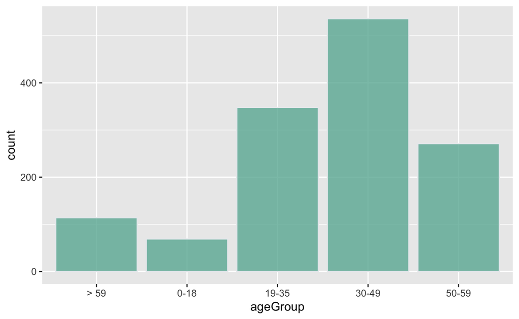

```r
data %>%
  mutate(
    ageGroup = dplyr::case_when(
      age <= 18 ~ "0-18",
      age > 18 & age <= 29 ~ "19-35",
      age > 29 & age <= 49 ~ "30-49",
      age > 49 & age <= 59 ~ "50-59",
      age > 59 ~ "> 59"
    )) %>%
  ggplot(aes(x=ageGroup)) +
  geom_bar(fill="#69b3a2", color="#e9ecef", alpha=0.8)
```

### Smoking based charts

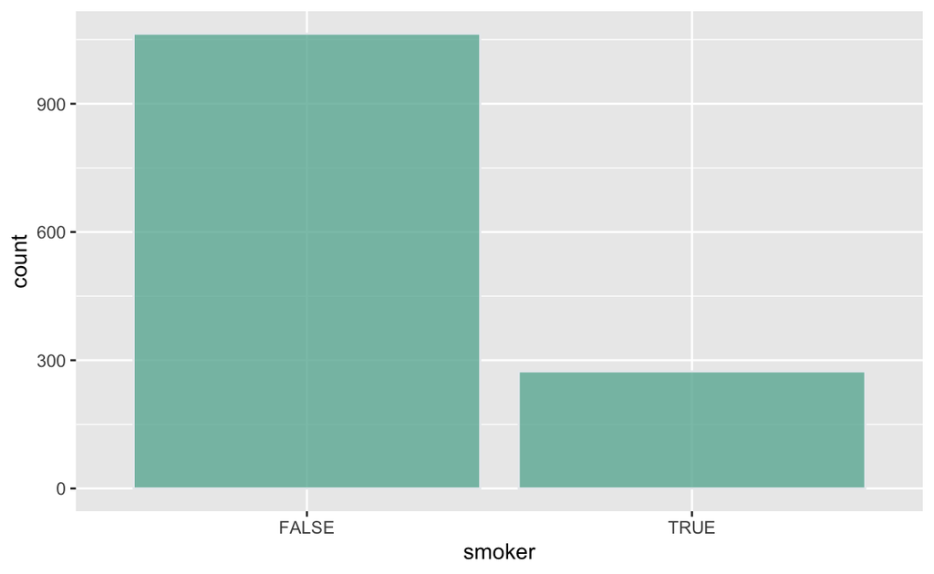

```r
data %>%
    ggplot(aes(x=smoker)) +
    geom_bar(fill="#69b3a2", color="#e9ecef", alpha=0.8)
```

```r
summary(data$smoker)
```

```
   Mode   FALSE    TRUE
logical    1064     274
```

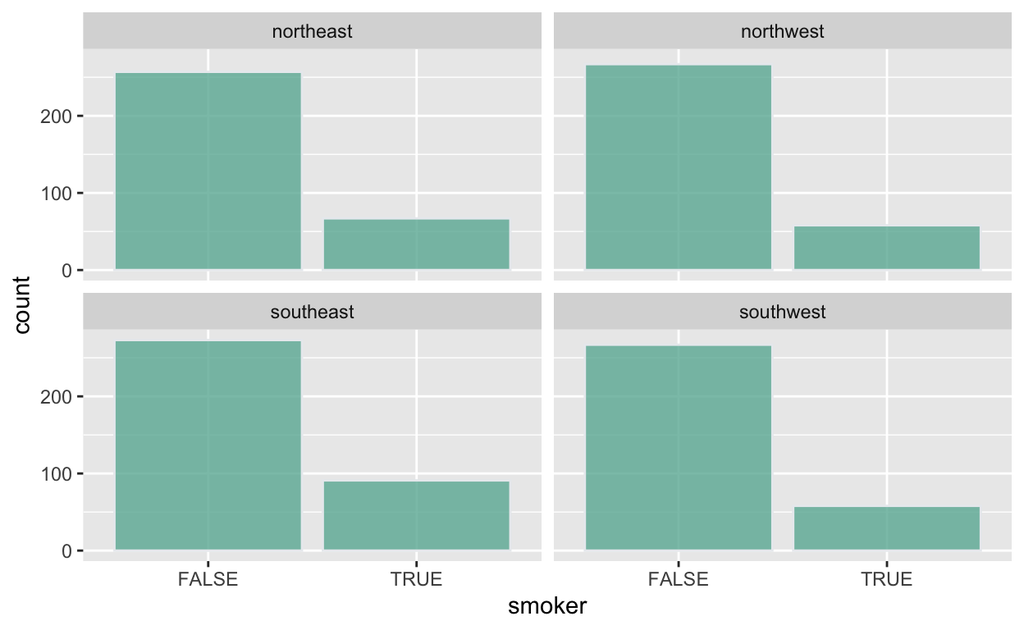

```r
data %>%
    ggplot(aes(x=smoker,)) +
    geom_bar(fill="#69b3a2", color="#e9ecef", alpha=0.8) +
    facet_wrap(~region)
```

### Children related charts

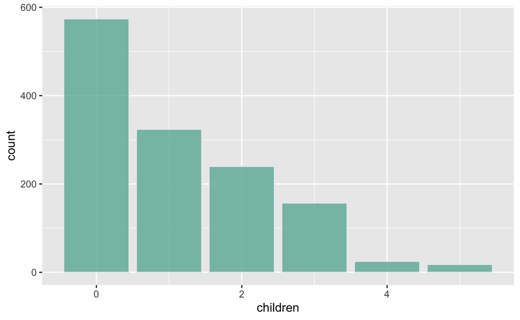

```r
data %>%
    ggplot(aes(x=children)) +
    geom_bar(fill="#69b3a2", color="#e9ecef", alpha=0.8)
```

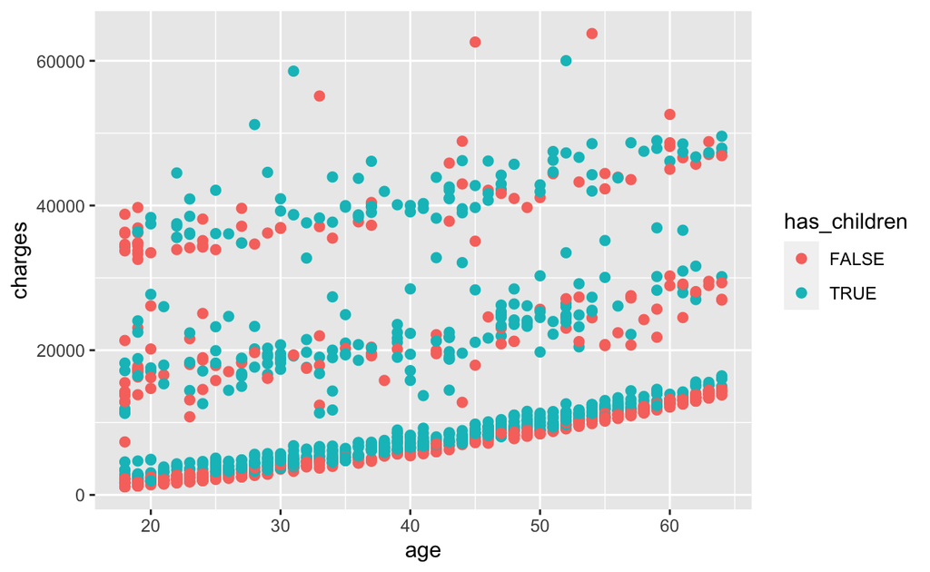

```r
data %>%
    ggplot(aes(x=age, y=charges, color=has_children)) +
    geom_point(size=2)
```

### Regional based charts

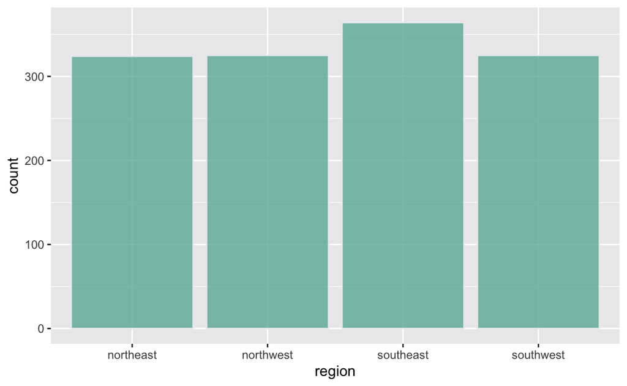

```r
data %>%
    ggplot(aes(x=region)) +
    geom_bar(fill="#69b3a2", color="#e9ecef", alpha=0.8)
```

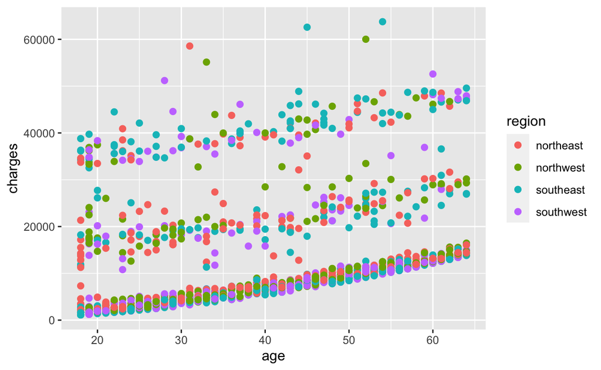

```r
data %>%
    ggplot(aes(x=age, y=charges, color=region)) +
    geom_point(size=2)
```